# Modeling individual instances of colonizations and extinctions

Question: do species traits intereact with changes in temperature (current or past) to determine whether or not a given species colonizes a new region in a given year?

binomial regressions:

colonization in a given year? (yes/no) ~ mean temp of year of trawl x traits + max temp of year of trawl x traits + min temp of year of trawl x traits + change in mean temp from last year x traits + lags + traits

extinction in a given year? (yes/no) ~ mean temp of year of trawl x traits + max temp of year of trawl x traits + min temp of year of trawl x traits + change in mean temp from last year x traits + lags + traits

Traits to use? Ideal: generalism dispersal syndrome longevity body size generation time trophic level current range size mobility (fish, yes/no)

What we actually have from Tim: (** = ideal) trophic level: feeding.mode (generalism?) **tl (trophic level)** Reproduction: (probably whichever we have more data for) spawning.type (open_water/substratum, etc. ) **egg.size** Growth: Linf (body size) Lmax (body size)* K (growth rate, 1/y) Lm (length at maturity) **Tmax (maximum age) tm (age maturity)**

*NB: I’m noticing that some species have multiple records in Tim’s database, and that some stats are not quite matching up with what I find on fishbase.org (ie BSB max size and such)*

```r
library(MuMIn)
library(lme4)
library(dplyr)
library(tidyr)
library(faraway)
library(data.table)
traits <- read.csv("traits_formanip.csv")
load("col_ext/hauls.Rdata")
```

[output not shown]

Let’s link species data from spp_master to temp data with lags and changes

```r
#match region names between two data tables
reg <- levels(as.factor(spp_master$reg))
region <- c("AFSC_Aleutians","AFSC_EBS", "SEFSC_GOMex", "AFSC_GOA", "NEFSC_NEUS", "DFO_Newfoundland", "SCDNR_SEUS", "DFO_ScotianShelf", "AFSC_WCTri")
regions.dt <- data.table(reg, region)
hauls <- hauls[regions.dt, nomatch = 0, on = c("region")]
hauls[, reg := as.factor(reg)] #make region a factor in hauls
```

Just realizing now that I currently have data from 12 months before each trawl event. This isn’t appropriate, as my colonization/extinction data is per year. FOR NOW (before I speak with Malin, update spoke to Malin he agreed that this worked), I will just use earliest month in each year.

```r
#keep one line of data for each year/region combo, and pick it based on smaller month value
hauls2 <- hauls[hauls[, .I[1], by = c("year", "region")]$V1]
cols <- c(5,38:286)
hauls2.r <- hauls2[, ..cols] #.. pulls in variable vs column name
```

```r
#make sure data type for reg and year in both are consistent
hauls2.r$year <- as.numeric(as.character(hauls2.r$year))
spp_master[, reg := as.factor(reg)]
#r combine species data with temp data
spp_master_ztemp <- spp_master[hauls2.r, nomatch = 0, on = c("reg", "year")]
head(spp_master_ztemp)
save(spp_master_ztemp, file = "spp_master_ztemp.Rdata")
```

First, let’s ignore traits, and just look at temperature as predictors of yes no colonization and yes no extinction Colonization in this year: col Goes extinct in this year (here last year, gone now) : now_ext Mean temp: mean_sbt_temp Max temp: max_sbt_temp Min temp: min_sbt_temp Seasonality: seas_sbt_temp

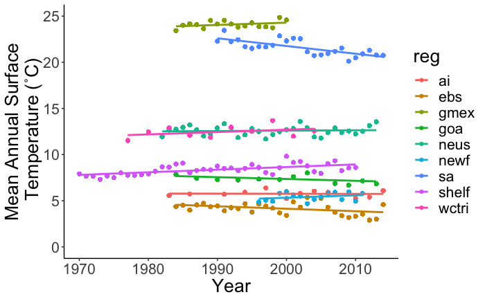

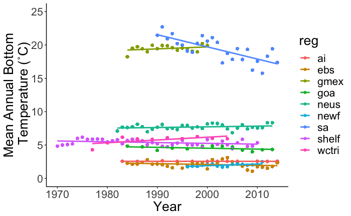

Get to know facet wrap but with facet wrap instead

[figure not shown]

What about correlations among temperature variables?

```r
#surface
res <- cor(spp_master_ztemp[,45:48])
res
#bottom
res2 <- cor(spp_master_ztemp[,169:172])
res2
```

Surface mean_sst_temp max_sst_temp min_sst_temp seas_sst_temp mean_sst_temp 1.0000000 0.9673832 0.96748430 0.18164518 max_sst_temp 0.9673832 1.0000000 0.87800968 0.41934324 min_sst_temp 0.9674843 0.8780097 1.00000000 -0.06633786 seas_sst_temp 0.1816452 0.4193432 -0.06633786 1.00000000

Mean is well correlated with max, and min both (0.96) Max and min are medium correlated, but I’ll still keep it in (0.87)

I will use max, min, seas

Bottom mean_sbt_temp max_sbt_temp min_sbt_temp seas_sbt_temp mean_sbt_temp 1.0000000 0.9935599 0.9869266 0.8085135 max_sbt_temp 0.9935599 1.0000000 0.9655348 0.8669641 min_sbt_temp 0.9869266 0.9655348 1.0000000 0.7073712 seas_sbt_temp 0.8085135 0.8669641 0.7073712 1.0000000

Mean is well correlated with max (0.99) and min (0.98) Max and min are well correlated with each other (0.96) Seasonality is most correlated with max (0.86), and then mean (0.80) and then min (0.70)

I will use min, and seas (least correlated)

Colonization base mod surface

```r
col_mod_base_sst <- glmer(col ~ max_sst_temp + min_sst_temp + seas_sst_temp + (1|year) + (1|reg), data = spp_master_ztemp, family = "binomial")
#rank deficient, so dropping a column
summary(col_mod_base_sst)
AICc(col_mod_base_sst)
```

Extinction base mod

```r
ext_mod_base_sst <- glmer(now_ext ~ max_sst_temp + min_sst_temp + seas_sst_temp + (1|reg) + (1|year), data = spp_master_ztemp, family = binomial)
summary(ext_mod_base_sst)
AICc(ext_mod_base_sst)
```

The above models perform really poorly, but this doesn’t really surprise me. I think change in temperature is a bigger deal.

```r
colnames(spp_master_ztemp)
```

# START HERE

Now, let’s play around with dredge.

```r
#I want to look at possible predictors
dredgesubset <- spp_master_ztemp[,c(1:3,6,45:168)] # this will have to change
#let's set the NA setting correctly
options(na.action = "na.fail")
#fitting global model
fm1_col <- glmer(col ~ . + (1|reg) + (1|year), family = binomial, data = dredgesubset)
#fixed-effect model matrix is rank deficient so dropping 102 columns / coefficients
#I have to trick model here so that it doesn't think it's rank deficient
vars <- colnames(spp_master_ztemp[,45:292])
form<-formula(paste0('col~',paste0(vars,collapse='+'),'+(1|reg)+(1|year)'))
attr(fm1_col@frame,"formula")<-form

#include only models with 1 term (and intercept)
dd <- dredge(fm1_col, m.lim = c(0, 1))

subset(dd, delta < 2)

# Visualize the model selection table:

par(mar = c(3,5,6,4))
plot(dd.col, labAsExpr = TRUE)

# Model average models with delta AICc < 2
model.avg(dd.col, subset = delta < 2)

#or as a 95% confidence set:
model.avg(dd.col, subset = cumsum(weight) <= .95) # get averaged coefficients

#'Best' model
summary(get.models(dd.col, 1)[[1]])
```

Now a dredge for extinction

```r
#fitting global model
fm1_ext <- glmm(now_ext ~  + (1|reg) + (1|year), family = binomial, data = dredgesubset)
dd.ext <- dredge(fm1_ext)

subset(dd.ext, delta < 2)

# Visualize the model selection table:

par(mar = c(3,5,6,4))
plot(dd.ext, labAsExpr = TRUE)

# Model average models with delta AICc < 2
model.avg(dd.ext, subset = delta < 2)

#or as a 95% confidence set:
model.avg(dd.ext, subset = cumsum(weight) <= .95) # get averaged coefficients

#'Best' model
summary(get.models(dd.ext, 1)[[1]])
```

Can’t get dredge to work, so doing model by model instead.

Here, looking at surface extinction

```r
#looping through all possible extinction variables with single variables
surface_variables <- colnames(spp_master_ztemp[,45:168]) #same as above

surface_extinction_model_comparison <- as.data.table(matrix(nrow = length(surface_variables)))
surface_extinction_model_comparison[, variable:=as.factor(V1)][, coef:=as.numeric(V1)][, p_value:=as.numeric(V1)][, AICc:=as.numeric(V1)]
surface_extinction_model_comparison[, V1 := NULL]

for (i in 1:length(surface_variables)){
  mod <- glmer(now_ext ~ get(surface_variables[i]) + (1|reg) + (1|year_factor), family = binomial, data = spp_master_ztemp)
  surface_extinction_model_comparison[i,variable := surface_variables[i]]
  surface_extinction_model_comparison[i,coef := coef(summary(mod))[,"Estimate"][2]]
  surface_extinction_model_comparison[i,p_value := coef(summary(mod))[,"Pr(>|z|)"][2]]
  surface_extinction_model_comparison[i,AICc := AICc(mod)]

  print(paste(i, length(surface_variables), sep = "/"))

}
```

Here, looking at bottom temp colonization

```r
#looping through all possible colonization variables with single variables
bottom_variables <- colnames(spp_master_ztemp[,169:292]) #same as above

bottom_colonization_model_comparison <- as.data.table(matrix(nrow = length(bottom_variables)))
bottom_colonization_model_comparison[, variable:=as.factor(V1)][, coef:=as.numeric(V1)][, p_value:=as.numeric(V1)][, AICc:=as.numeric(V1)]
bottom_colonization_model_comparison[, V1 := NULL]

for (i in 1:length(bottom_variables)){
  mod <- glmer(col ~ get(bottom_variables[i]) + (1|reg) + (1|year_factor), family = binomial, data = spp_master_ztemp)
  bottom_colonization_model_comparison[i,variable := bottom_variables[i]]
  bottom_colonization_model_comparison[i,coef := coef(summary(mod))[,"Estimate"][2]]
  bottom_colonization_model_comparison[i,p_value := coef(summary(mod))[,"Pr(>|z|)"][2]]
  bottom_colonization_model_comparison[i,AICc := AICc(mod)]

  print(paste(i, length(bottom_variables), sep = "/"))

}
```

Finally, looking at bottom temp extinction

```r
#looping through all possible extinction variables with single variables
bottom_variables <- colnames(spp_master_ztemp[,169:292]) #same as above

bottom_extinction_model_comparison <- as.data.table(matrix(nrow = length(bottom_variables)))
bottom_extinction_model_comparison[, variable:=as.factor(V1)][, coef:=as.numeric(V1)][, p_value:=as.numeric(V1)][, AICc:=as.numeric(V1)]
bottom_extinction_model_comparison[, V1 := NULL]

for (i in 1:length(bottom_variables)){
  mod <- glmer(now_ext ~ get(bottom_variables[i]) + (1|reg) + (1|year_factor), family = binomial, data = spp_master_ztemp)
  bottom_extinction_model_comparison[i,variable := bottom_variables[i]]
  bottom_extinction_model_comparison[i,coef := coef(summary(mod))[,"Estimate"][2]]
  bottom_extinction_model_comparison[i,p_value := coef(summary(mod))[,"Pr(>|z|)"][2]]
  bottom_extinction_model_comparison[i,AICc := AICc(mod)]

  print(paste(i, length(bottom_variables), sep = "/"))

}
```

Top models with single variables

```r
head(surface_colonization_model_comparison[order(AICc)])

#mean highly correlated with max, so looking just at max, lag1 and lag8 are best
```

Merge surface and bottom for colonization

```r
colonization_model_comparisons <- rbind(bottom_colonization_model_comparison, surface_colonization_model_comparison)
#lowest AICc
head(colonization_model_comparisons[order(AICc)], 30)
```

Now, I should look at relative variable importance:

- Burnham and Anderson (2002), Page 169: This ballancing puts each variable on equal footing.
- Akaike weights are can be used in model averaging. They represent the relative likelihood of a model. To calculate them, for each model first calculate the relative likelihood of the model, which is just exp( -0.5 * ∆AIC score for that model). The Akaike weight for a model is this value divided by the sum of these values across all models.

```r
#get rid of mean
colonization_model_comparisons <- colonization_model_comparisons %>%
  filter(!grepl("mean", variable))

colonization_model_comparisons <- data.table(colonization_model_comparisons)

#add ∆AIC to tables
min_col_AICc <- min(colonization_model_comparisons[, AICc])
colonization_model_comparisons[,"deltaAICc" := (AICc - min_col_AICc)]

#add relative likelihood exp( -0.5 * ∆AIC score for that model)
colonization_model_comparisons[,"rel_likelihood" := exp((-0.5 * deltaAICc))]
#sum relative likelihoods across all models
colonization_model_comparisons.likelihoodsum <- sum(colonization_model_comparisons[, rel_likelihood])
#Akaike weight for a model is this rel_likelihood devided by the sum of these values across all models
colonization_model_comparisons[,"akaike_weight" := rel_likelihood/colonization_model_comparisons.likelihoodsum]

#I want to look at relative importance FOR
#bottom/surface (bottom = includes sbt, grepl("sbt", variable))
col_bottom_importance <- sum(colonization_model_comparisons[grep("sbt", variable), ]$akaike_weight)
col_surface_importance <- sum(colonization_model_comparisons[grep("sst", variable), ]$akaike_weight)

#lag/not lagged (grepl("lag", variable))
col_lag_importance <- sum(colonization_model_comparisons[grep("lag", variable), ]$akaike_weight)

#absolute (grepl("abs", variable))
col_abs_importance <- sum(colonization_model_comparisons[grep("abs", variable), ]$akaike_weight)

#raw (!grepl("change"))
col_raw_importance <- sum(colonization_model_comparisons[!grep("change", variable), ]$akaike_weight)

#change (grepl("change", variable), (!grepl("abs")))
col_change_importance <- (1 - (col_abs_importance + col_raw_importance))
```

Surface importance = 0.02 Bottom importance = 0.97 Lag importance = 0.03 Absolute change importance = 0.99 Raw temp importance = 0.003 Change importance (no abs) = 0.005

Merge surface and bottom for extinction

```r
extinction_model_comparisons <- rbind(bottom_extinction_model_comparison, surface_extinction_model_comparison)
head(extinction_model_comparisons[order(AICc)], 30)
```

Relative variable importance for extinction models

```r
#get rid of mean
extinction_model_comparisons <- extinction_model_comparisons %>%
  filter(!grepl("mean", variable))

extinction_model_comparisons <- data.table(extinction_model_comparisons)

#add ∆AIC to tables
min_ext_AICc <- min(extinction_model_comparisons[, AICc])
extinction_model_comparisons[,"deltaAICc" := (AICc - min_ext_AICc)]

#add relative likelihood exp( -0.5 * ∆AIC score for that model)
extinction_model_comparisons[,"rel_likelihood" := exp((-0.5 * deltaAICc))]
#sum relative likelihoods across all models
extinction_model_comparisons.likelihoodsum <- sum(extinction_model_comparisons[, rel_likelihood])
#Akaike weight for a model is this rel_likelihood devided by the sum of these values across all models
extinction_model_comparisons[,"akaike_weight" := rel_likelihood/extinction_model_comparisons.likelihoodsum]

#I want to look at relative importance FOR
#bottom/surface (bottom = includes sbt, grepl("sbt", variable))
ext_bottom_importance <- sum(extinction_model_comparisons[grep("sbt", variable), ]$akaike_weight)
ext_surface_importance <- sum(extinction_model_comparisons[grep("sst", variable), ]$akaike_weight)

#lag/not lagged (grepl("lag", variable))
ext_lag_importance <- sum(extinction_model_comparisons[grep("lag", variable), ]$akaike_weight)

#absolute (grepl("abs", variable))
ext_abs_importance <- sum(extinction_model_comparisons[grep("abs", variable), ]$akaike_weight)

#raw (!grepl("change"))
ext_raw_importance <- sum(extinction_model_comparisons[!grep("change", variable), ]$akaike_weight)

#change (grepl("change", variable), (!grepl("abs")))
ext_change_importance <- (1 - (ext_abs_importance + ext_raw_importance))
```

Surface importance = 0.37 Bottom importance = 0.63 Lag importance = 0.90 Absolute change importance = 0.47 Raw temp importance = 0.20 Change importance (no abs) = 0.34

Let’s see how the RVI importance varies by looking at specific lag values

```r
#first, table for lags
lags_v_RVI <- data.table(col_lag = c(0:9), col_RVI = 0, ext_RVI = 0)
#colonization
lags_v_RVI[1,2] <- 1-sum(colonization_model_comparisons[grep("lag", variable), ]$akaike_weight)
lags_v_RVI[2,2] <- sum(colonization_model_comparisons[grep("lag1", variable), ]$akaike_weight)
lags_v_RVI[3,2] <- sum(colonization_model_comparisons[grep("lag2", variable), ]$akaike_weight)
lags_v_RVI[4,2] <- sum(colonization_model_comparisons[grep("lag3", variable), ]$akaike_weight)
lags_v_RVI[5,2] <- sum(colonization_model_comparisons[grep("lag4", variable), ]$akaike_weight)
lags_v_RVI[6,2] <- sum(colonization_model_comparisons[grep("lag5", variable), ]$akaike_weight)
lags_v_RVI[7,2] <- sum(colonization_model_comparisons[grep("lag6", variable), ]$akaike_weight)
lags_v_RVI[8,2] <- sum(colonization_model_comparisons[grep("lag7", variable), ]$akaike_weight)
lags_v_RVI[9,2] <- sum(colonization_model_comparisons[grep("lag8", variable), ]$akaike_weight)
lags_v_RVI[10,2] <- sum(colonization_model_comparisons[grep("lag9", variable), ]$akaike_weight)
#extinction
lags_v_RVI[1,3] <- 1-sum(extinction_model_comparisons[grep("lag", variable), ]$akaike_weight)
lags_v_RVI[2,3] <- sum(extinction_model_comparisons[grep("lag1", variable), ]$akaike_weight)
lags_v_RVI[3,3] <- sum(extinction_model_comparisons[grep("lag2", variable), ]$akaike_weight)
lags_v_RVI[4,3] <- sum(extinction_model_comparisons[grep("lag3", variable), ]$akaike_weight)
lags_v_RVI[5,3] <- sum(extinction_model_comparisons[grep("lag4", variable), ]$akaike_weight)
lags_v_RVI[6,3] <- sum(extinction_model_comparisons[grep("lag5", variable), ]$akaike_weight)
lags_v_RVI[7,3] <- sum(extinction_model_comparisons[grep("lag6", variable), ]$akaike_weight)
lags_v_RVI[8,3] <- sum(extinction_model_comparisons[grep("lag7", variable), ]$akaike_weight)
lags_v_RVI[9,3] <- sum(extinction_model_comparisons[grep("lag8", variable), ]$akaike_weight)
lags_v_RVI[10,3] <- sum(extinction_model_comparisons[grep("lag9", variable), ]$akaike_weight)

ggplot(data = lags_v_RVI, aes(x = col_lag)) +
  geom_line(aes(y = col_RVI), col = "blue") +
  geom_line(aes(y = ext_RVI), col = "red") +
  labs(x = "Lag", y = "Relative Variable Importance") +
  scale_color_discrete() + #how to make a legend
  theme_bw()
```

## Below I’m doing a more“organic” and less perscriptive dredge

What model performs better? a model with changes in the past year? or a model with changes in the year before last?

First, let’s make a model with changes from the year before last for colonization

```r
col_mod_change_abs_lag1 <- glmer(col ~ sst_mean_change_lag1_abs + sst_max_change_lag1_abs + sst_min_change_lag1_abs + sst_seas_change_lag1_abs + (1|reg) + (1|year), data = spp_master_ztemp, family = binomial)
summary(col_mod_change_abs_lag1)
AICc(col_mod_change_abs_lag1)
```

Not much info from summary, but let’s compare using AICc with other model

```r
AICc(col_mod_change_abs, col_mod_change_abs_lag1)
```

Poor results here! What about extinction?

```r
ext_mod_change_abs_lag1 <- glmer(now_ext ~ sst_mean_change_lag1_abs + sst_max_change_lag1_abs + sst_min_change_lag1_abs + sst_seas_change_lag1_abs + (1|reg) + (1|year), data = spp_master_ztemp, family = binomial)
summary(ext_mod_change_abs_lag1)
AICc(ext_mod_change_abs_lag1)
```

For extinction and lag 1 of changes, both absolute value of change in mean experienced last year and absolute value of change in max temp experienced last year appear significant As absolute value of change in mean experienced last year increases, likelihood of extinction decreases As absolute value of change in max temp experienced last year increases, likelihood of extinction increases

But what about comparing this to other model?

```r
AICc(ext_mod_change_abs, ext_mod_change_abs_lag1)
```

Here, unlike colonization, it appears that changes experienced LAST year are better than changes experienced this year at predicting extinction

Let’s go back once more in time for each for kicks

Colonization based on changes in temp experienced between 2-3 years ago

```r
col_mod_change_abs_lag2 <- glmer(col ~ sst_mean_change_lag2_abs + sst_max_change_lag2_abs + sst_min_change_lag2_abs + sst_seas_change_lag2_abs + (1|reg) + (1|year), data = spp_master_ztemp, family = binomial)
summary(col_mod_change_abs_lag2)
AICc(col_mod_change_abs_lag2)
```

This is still bad, but what about one more lag

```r
col_mod_change_abs_lag3 <- glmer(col ~ sst_mean_change_lag3_abs + sst_max_change_lag3_abs + sst_min_change_lag3_abs + sst_seas_change_lag3_abs + (1|reg) + (1|year), data = spp_master_ztemp, family = binomial)
summary(col_mod_change_abs_lag3)
AICc(col_mod_change_abs_lag3)
```

And compare this using AICc to other models

```r
AICc(col_mod_change_abs, col_mod_change_abs_lag1, col_mod_change_abs_lag2, col_mod_change_abs_lag3)
```

Both incorporating lags in changes are equally poor for colonization, so we’ll stick with most recent changes in temp variables.

Next step, I will take away variables and see what’s best for colonization using AIC. For dredge, I will check all combinations.

```r
summary(col_mod_change_abs)
```

```r
#remember, variables with best P values for colonization ARE seas, and then max, and then mean (min not significant)
#three variables, 4 models
col_mod_change_abs_3_var <- glmer(col ~ sst_mean_change_abs + sst_max_change_abs + sst_seas_change_abs + (1 | reg) + (1 | year), family = binomial, data = spp_master_ztemp)
col_mod_change_abs_3_var2 <- glmer(col ~ sst_mean_change_abs + sst_min_change_abs + sst_seas_change_abs + (1 | reg) + (1 | year), family = binomial, data = spp_master_ztemp)
col_mod_change_abs_3_var3 <- glmer(col ~ sst_mean_change_abs + sst_max_change_abs + sst_min_change_abs + (1 | reg) + (1 | year), family = binomial, data = spp_master_ztemp)
col_mod_change_abs_3_var4 <- glmer(col ~ sst_seas_change_abs + sst_max_change_abs + sst_seas_change_abs + (1 | reg) + (1 | year), family = binomial, data = spp_master_ztemp)

AICc(col_mod_change_abs_3_var, col_mod_change_abs_3_var2, col_mod_change_abs_3_var3, col_mod_change_abs_3_var4)

#two variables, 6 models
col_mod_change_abs_2_var <- glmer(col ~ sst_max_change_abs + sst_seas_change_abs + (1 | reg) + (1 | year), family = binomial, data = spp_master_ztemp)
col_mod_change_abs_2_var2 <- glmer(col ~ sst_max_change_abs + sst_min_change_abs + (1 | reg) + (1 | year), family = binomial, data = spp_master_ztemp)
col_mod_change_abs_2_var3 <- glmer(col ~ sst_max_change_abs + sst_mean_change_abs + (1 | reg) + (1 | year), family = binomial, data = spp_master_ztemp)
col_mod_change_abs_2_var4 <- glmer(col ~ sst_seas_change_abs + sst_min_change_abs + (1 | reg) + (1 | year), family = binomial, data = spp_master_ztemp)
col_mod_change_abs_2_var5 <- glmer(col ~ sst_seas_change_abs + sst_mean_change_abs + (1 | reg) + (1 | year), family = binomial, data = spp_master_ztemp)
col_mod_change_abs_2_var6 <- glmer(col ~ sst_min_change_abs + sst_mean_change_abs + (1 | reg) + (1 | year), family = binomial, data = spp_master_ztemp)

AICc(col_mod_change_abs_2_var, col_mod_change_abs_2_var2, col_mod_change_abs_2_var3, col_mod_change_abs_2_var4, col_mod_change_abs_2_var5, col_mod_change_abs_2_var6)

#one variable, 4 models
col_mod_change_abs_1_var <- glmer(col ~ sst_seas_change_abs + (1 | reg) + (1 | year), family = binomial, data = spp_master_ztemp)
col_mod_change_abs_1_var2 <- glmer(col ~ sst_mean_change_abs + (1 | reg) + (1 | year), family = binomial, data = spp_master_ztemp)
col_mod_change_abs_1_var3 <- glmer(col ~ sst_min_change_abs + (1 | reg) + (1 | year), family = binomial, data = spp_master_ztemp)
col_mod_change_abs_1_var4 <- glmer(col ~ sst_max_change_abs + (1 | reg) + (1 | year), family = binomial, data = spp_master_ztemp)

AICc(col_mod_change_abs_1_var, col_mod_change_abs_1_var2, col_mod_change_abs_1_var3, col_mod_change_abs_1_var4)

AICc(col_mod_change_abs_1_var, col_mod_change_abs_2_var, col_mod_change_abs_3_var, col_mod_change_abs)
summary(col_mod_change_abs_3_var)
```

**The best model uses only seasonality as a predictor** col_mod_change_abs_1_var <- glmer(col ~ sst_seas_change_abs + (1 | reg) + (1 | year), family = binomial, data = spp_master_ztemp)

Extinction based on changes in temp experienced between 2-3 years ago

```r
ext_mod_change_abs_lag2 <- glmer(now_ext ~ sst_mean_change_lag2_abs + sst_max_change_lag2_abs + sst_min_change_lag2_abs + sst_seas_change_lag2_abs + (1|reg) + (1|year), data = spp_master_ztemp, family = binomial)
summary(ext_mod_change_abs_lag3)
AICc(ext_mod_change_abs, ext_mod_change_abs_lag1, ext_mod_change_abs_lag2, ext_mod_change_abs_lag3)
```

And compare this using AICc to other models

```r
AICc(ext_mod_change_abs, ext_mod_change_abs_lag1, ext_mod_change_abs_lag2)
```

```r
ext_mod_change_abs_lag3 <- glmer(now_ext ~ sst_mean_change_lag3_abs + sst_max_change_lag3_abs + sst_min_change_lag3_abs + sst_seas_change_lag3_abs + (1|reg) + (1|year), data = spp_master_ztemp, family = binomial)
summary(ext_mod_change_abs_lag3)
AICc(ext_mod_change_abs, ext_mod_change_abs_lag1, ext_mod_change_abs_lag2, ext_mod_change_abs_lag3)
```

The best is lag 2, so the change from 2-3 years ago is best at determining extinction probability

Next step, I will take away variables and see what’s best for extinction using AIC. For dredge, I will check all combinations.

```r
summary(ext_mod_change_abs_lag2)
```

```r
#remember, variables with best P values for extinction with 2 lag are max change lag 2 abs, mean change lag 2 abs, seas change lag 2 abs, and last min change lag 2 abs

#for three variables (four models)
ext_mod_change_lag2_abs_3_var <- glmer(now_ext ~ sst_mean_change_lag2_abs + sst_max_change_lag2_abs + sst_seas_change_lag2_abs + (1 | reg) + (1 | year), family = binomial, data = spp_master_ztemp)
ext_mod_change_lag2_abs_3_var2 <- glmer(now_ext ~ sst_mean_change_lag2_abs + sst_min_change_lag2_abs + sst_seas_change_lag2_abs + (1 | reg) + (1 | year), family = binomial, data = spp_master_ztemp)
ext_mod_change_lag2_abs_3_var3 <- glmer(now_ext ~ sst_min_change_lag2_abs + sst_max_change_lag2_abs + sst_seas_change_lag2_abs + (1 | reg) + (1 | year), family = binomial, data = spp_master_ztemp)
ext_mod_change_lag2_abs_3_var4 <- glmer(now_ext ~ sst_mean_change_lag2_abs + sst_max_change_lag2_abs + sst_min_change_lag2_abs + (1 | reg) + (1 | year), family = binomial, data = spp_master_ztemp)
AICc(ext_mod_change_lag2_abs_3_var2, ext_mod_change_lag2_abs_3_var3, ext_mod_change_lag2_abs_3_var4, ext_mod_change_lag2_abs_3_var)

#for two variables (six models)
ext_mod_change_lag2_abs_2_var <- glmer(now_ext ~ sst_mean_change_lag2_abs + sst_max_change_lag2_abs + (1 | reg) + (1 | year), family = binomial, data = spp_master_ztemp)
ext_mod_change_lag2_abs_2_var2 <- glmer(now_ext ~ sst_mean_change_lag2_abs + sst_min_change_lag2_abs + (1 | reg) + (1 | year), family = binomial, data = spp_master_ztemp)
ext_mod_change_lag2_abs_2_var3 <- glmer(now_ext ~ sst_mean_change_lag2_abs + sst_seas_change_lag2_abs + (1 | reg) + (1 | year), family = binomial, data = spp_master_ztemp)
ext_mod_change_lag2_abs_2_var4 <- glmer(now_ext ~ sst_max_change_lag2_abs + sst_min_change_lag2_abs + (1 | reg) + (1 | year), family = binomial, data = spp_master_ztemp)
ext_mod_change_lag2_abs_2_var5 <- glmer(now_ext ~ sst_max_change_lag2_abs + sst_seas_change_lag2_abs + (1 | reg) + (1 | year), family = binomial, data = spp_master_ztemp)
ext_mod_change_lag2_abs_2_var6 <- glmer(now_ext ~ sst_min_change_lag2_abs + sst_seas_change_lag2_abs + (1 | reg) + (1 | year), family = binomial, data = spp_master_ztemp)

AICc(ext_mod_change_lag2_abs_2_var, ext_mod_change_lag2_abs_2_var2,ext_mod_change_lag2_abs_2_var3,ext_mod_change_lag2_abs_2_var4,ext_mod_change_lag2_abs_2_var5,ext_mod_change_lag2_abs_2_var6)

#for one variable (four models)
ext_mod_change_lag2_abs_1_var <- glmer(now_ext ~ sst_max_change_lag2_abs + (1 | reg) + (1 | year), family = binomial, data = spp_master_ztemp)
ext_mod_change_lag2_abs_1_var2 <- glmer(now_ext ~ sst_mean_change_lag2_abs + (1 | reg) + (1 | year), family = binomial, data = spp_master_ztemp)
ext_mod_change_lag2_abs_1_var3 <- glmer(now_ext ~ sst_min_change_lag2_abs + (1 | reg) + (1 | year), family = binomial, data = spp_master_ztemp)
ext_mod_change_lag2_abs_1_var4 <- glmer(now_ext ~ sst_seas_change_lag2_abs + (1 | reg) + (1 | year), family = binomial, data = spp_master_ztemp)

AICc(ext_mod_change_lag2_abs_1_var,ext_mod_change_lag2_abs_1_var2,ext_mod_change_lag2_abs_1_var3,ext_mod_change_lag2_abs_1_var4)

#Now comparing best of each level of variables
AICc(ext_mod_change_lag2_abs_3_var, ext_mod_change_lag2_abs_1_var, ext_mod_change_lag2_abs_2_var, ext_mod_change_abs_lag2)
AICc()
summary(ext_mod_change_lag2_abs_3_var)
```

The best model is less clear here, ext_mod_change_lag2_abs_2_var has the lowest AICc, but, it’s not substantially lower, and ext_mod_change_lag2_abs_1_var has fewer predictors, so let’s go with that **ext_mod_change_lag2_abs_1_var <- glmer(now_ext ~ sst_max_change_lag2_abs + (1 | reg) + (1 | year), family = binomial, data = spp_master_ztemp)**: best model for extinction

```r
summary(ext_mod_change_lag2_abs_1_var)
```

We’re able to explain 12% of variation in extinction from the change in maximum temperature between 2-3 years ago (extinction debt?)

**col_mod_change_abs_1_var <- glmer(col ~ sst_seas_change_abs + (1 | reg) + (1 | year), family = binomial, data = spp_master_ztemp)**: best model for colonization

```r
summary(col_mod_change_abs_1_var)
```

We’re able to explain 13% of the variation in colonization with change in seasonality from last year

Can we plot what we have so far?

Colonization: col_mod_change_abs_1_var <- glmer(col ~ sst_seas_change_abs + (1 | reg) + (1 | year), family = binomial, data = spp_master_ztemp)

x axis: absolute change in seasonality this past year y axis: likelihood of colonization in this year

```r
#probability density function for colonization
x <- c(seq(0,1, by=0.001))
k <- sum(spp_master_ztemp$col)
n <- length(complete.cases(spp_master_ztemp$col))
bdist <- dbeta(x,k+1,n-k+1)


plot(x,bdist, ylab="Density Distribution", xlab="Proportion Of Year/Species Combos Undergoing Colonization", pch='.')

p <- c(0.025,0.975)
confint <- qbeta(p,k+1,n-k+1)
abline(v=confint,col="red",lty=2)

min(spp_master_ztemp$sst_seas_change_abs, na.rm = T)
max(spp_master_ztemp$sst_seas_change_abs, na.rm = T)

w <- seq(0,7,0.01)

plot(x=spp_master_ztemp$sst_seas_change_abs, y=spp_master_ztemp$col)
lines(x=w, y=ilogit(-3.33061+0.12645*w))
```

Extinction: ext_mod_change_lag2_abs_1_var <- glmer(now_ext ~ sst_max_change_lag2_abs + (1 | reg) + (1 | year), family = binomial, data = spp_master_ztemp)

```r
#probability density function for colonization
x <- c(seq(0,1, by=0.001))
k <- sum(spp_master_ztemp$now_ext)
n <- length(complete.cases(spp_master_ztemp$now_ext))
bdist <- dbeta(x,k+1,n-k+1)


plot(x,bdist, ylab="Density Distribution", xlab="Proportion Of Year/Species Combos Undergoing Extinction", pch='.')

p <- c(0.025,0.975)
confint <- qbeta(p,k+1,n-k+1)
abline(v=confint,col="red",lty=2)

min(spp_master_ztemp$sst_max_change_abs, na.rm = T)
max(spp_master_ztemp$sst_max_change_abs, na.rm = T)

w <- seq(0,8,0.01)

plot(x=spp_master_ztemp$sst_max_change_abs, y=spp_master_ztemp$now_ext)
lines(x=w, y=ilogit(-4.25266+0.11950*w))
```

For each degree increase in temperature change of max, log odds of extinction is predicted to change by 0.11950, or we can say that for a one unit increase in temp change, the odds of having extinction (versus not becoming extinct) increase by a factor of 1.12.

Hard to interpret, these graphs are pretty lame, but big take aways are: 1. temperature change is better predictor than plain temperature 1. absolute value of temperature change is better predictor than just change 1. for colonization, temp change over past year is best predictor 1. for extinction, temp change experienced 2-3 years ago is best predictor 1. for colonization, of temp variables, change in seasonality is best predictor 1. for extinction, of temp variables, change in maximum temperature is best predictor _______________

Now we will see if adding traits can improve the model, we only have traits for fish at this point, so we only care about fish so let’s go back to earlier code to extract fish only

```r
load("fish_nofishkey.RData")
```

We will now limit spp_master_z to fish

```r
spp_master_ztemp_fishnofish <- left_join(spp_master_ztemp, fish_nofishkey, by = c("reg", "spp"))
spp_master_ztemp_fishnofish$fish <- as.factor(spp_master_ztemp_fishnofish$fish)
spp_master_ztemp_fishonly <- spp_master_ztemp_fishnofish %>%
  filter(fish == "Y")
?filter
summary(spp_master_ztemp_fishnofish$fish) # I have NA's but I will ignore for now
```

Let’s now link to traits!

```r
traits <- read.csv("traits_formanip.csv")
traits$spp <- paste(traits$genus, traits$species, sep = " ")
#restrict to LME 1:9 and 54 according to https://www.st.nmfs.noaa.gov/ecosystems/lme/
levels(as.factor(traits$lme))
traits_NA <- traits %>%
  dplyr::filter(lme < 10 | lme == 54) %>%
  group_by(spp) %>%
  filter(row_number() == 1) #this means we only have one observation per species

spp_master_ztemp_fishonly_traits <- left_join(spp_master_ztemp_fishonly, traits_NA, by = "spp")
```

Traits that actually look reasonable to use

feeding.mode: benthivorous, generalist, herbivorous, piscivorous, planktivorous *maybe make this into generalist or specialist? (only 2 NA’s) –> $generalist

tl: 2-4.65 (no NA’s)

egg.size: *(looks like I need to make this numeric or something) 111 NA’s

spawning.type ( open_water-substratum, guarder, nonguarder, internal_bearer, external_bearer) 63 NA’s

Lmax (2.5-1520) only 1 NA!

tmax (0.55 - 223) 181 NA’s

tm (156 NA’s)

Lm (712 NA’s) *exclude

Let’s simplify feeding.mode to just generalist vs. specialist

```r
spp_master_ztemp_fishonly_traits$generalist <- NA
spp_master_ztemp_fishonly_traits$generalist[spp_master_ztemp_fishonly_traits$feeding.mode == "generalists"] <- 1
spp_master_ztemp_fishonly_traits$generalist[spp_master_ztemp_fishonly_traits$feeding.mode != "generalists"] <- 0
```

Let’s look at egg size

```r
spp_master_ztemp_fishonly_traits$egg.size <- as.numeric(spp_master_ztemp_fishonly_traits$egg.size)
summary(spp_master_ztemp_fishonly_traits$egg.size)
#much better
```

For this analysis, I’m just going to look at trait values we have a lot of generalist tl spawning.type Lmax

Let’s first run best models now that we’re looking only at fish reminders of best models: col_mod_change_abs_1_var <- glmer(col ~ sst_seas_change_abs + (1 | reg) + (1 | year), family = binomial, data = spp_master_ztemp) ext_mod_change_lag2_abs_1_var <- glmer(now_ext ~ sst_max_change_lag2_abs + (1 | reg) + (1 | year), family = binomial, data = spp_master_ztemp)

First colonization

```r
col_mod_change_abs_1_var_fishonly <- glmer(col ~ sst_seas_change_abs + (1 | reg) + (1 | year), family = binomial, data = spp_master_ztemp_fishonly_traits)
summary(col_mod_change_abs_1_var_fishonly)
AICc(col_mod_change_abs_1_var_fishonly, col_mod_change_abs_1_var)
#unclear, but the AICc value for the fish only model is much better even though it appears dismal interms of p value, let's try with all variables again
col_mod_change_abs_fishonly <- glmer(col ~ sst_mean_change_abs + sst_max_change_abs + sst_min_change_abs + sst_seas_change_abs + (1|reg) + (1|year), data = spp_master_ztemp_fishonly_traits, family = binomial)
summary(col_mod_change_abs_fishonly) #nothing is significant
#still we'll try to add in traits
col_mod_change_abs_1_var_fishonly_wtraits <- glmer(col ~ sst_seas_change_abs*generalist + (1 | reg) + (1 | year), family = binomial, data = spp_master_ztemp_fishonly_traits)
summary(col_mod_change_abs_1_var_fishonly_wtraits)
summary(col_mod_change_abs_1_var_fishonly)
AICc(col_mod_change_abs_1_var_fishonly_wtraits, col_mod_change_abs_1_var_fishonly)
```

Let’s try the same with extinction

```r
ext_mod_change_lag2_abs_1_var_fishonly_wtraits <- glmer(now_ext ~ sst_max_change_lag2_abs*generalist + (1 | reg) + (1 | year), family = binomial, data = spp_master_ztemp_fishonly_traits)
summary(ext_mod_change_lag2_abs_1_var_fishonly_wtraits)
```

One idea would just be to seperate by mobility as Malin did in Nature 2019 Reminder, best Model Colonization: col_mod_change_abs_1_var <- glmer(col ~ sst_seas_change_abs + (1 | reg) + (1 | year), family = binomial, data = spp_master_ztemp)

```r
#import Malin's dataset
mobility_traits <- read.csv("dataset_1_traits_nature.csv")
spp_master_ztemp_fishnofish_mobility <- inner_join(spp_master_ztemp_fishnofish, mobility_traits, by = "spp")
col_mod_change_abs_1_var_mobility <- glmer(col ~ sst_seas_change_abs*fish + (1 | reg) + (1 | year), family = binomial, data = spp_master_ztemp_fishnofish)
summary(col_mod_change_abs_1_var_sessilemobile)
AICc(col_mod_change_abs_1_var_sessilemobile, col_mod_change_abs_1_var)
```

Including sessile/mobile improves our ability to predict likelihood of colonization

What about extinction?

```r
ext_mod_change_lag2_abs_1_var_sessilemobile <- glmer(now_ext ~ sst_max_change_lag2_abs*fish + (1 | reg) + (1 | year), family = binomial, data = spp_master_ztemp_fishnofish)
summary(ext_mod_change_lag2_abs_1_var_sessilemobile)
AICc(ext_mod_change_lag2_abs_1_var, ext_mod_change_lag2_abs_1_var_sessilemobile)
```

Here, sessile/mobile also improves fit and also the interaction with change in maximum temperature. The role of mobility changes with the size of the change in temperature between years.